# Exploration 2

Mannie Chomsin

1/26/2020

# Math 32

## Exploration 2

In this `exploration`, you are asked to

- find sample means and medians from a randomized data sample
- observe the differences in the practice of using means or medians
1. First,
   1. Type your name into the author field in the YAML parameters above
   2. Also save this file while replacing “template” with your full name (be sure to keep the *.rmd file format).
2. Demonstrate your understanding about the example code block below by adding at least 5 comments in the code block in your own words.

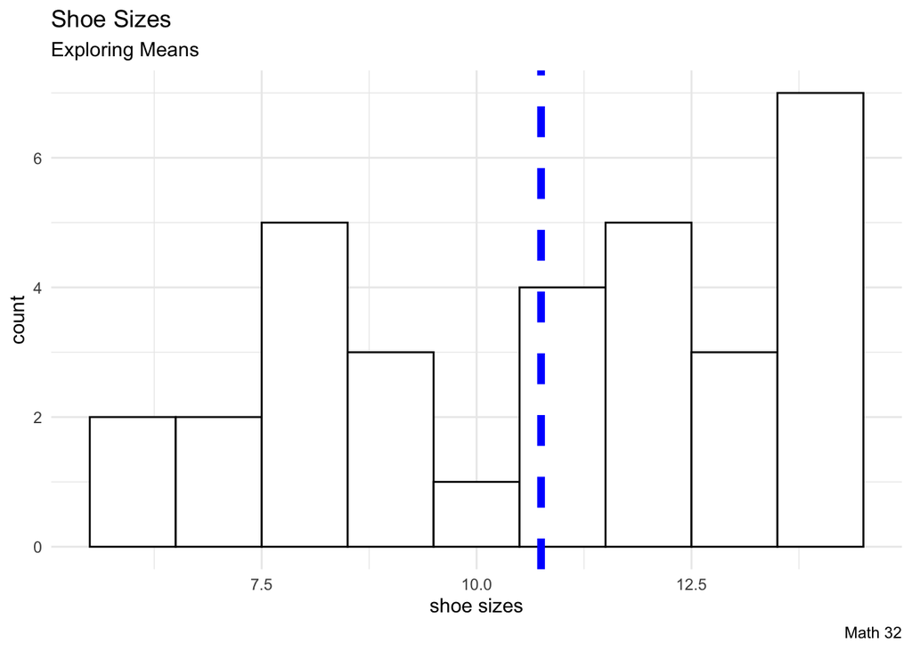

```r
library("ggplot2")

N <- 32

#creates an iteratible of 9 numbers (6 to 14)
shoe_sizes <- 6:14
#randomly picks a number from 6 to 14 (inclusive) 32 times (repeats allowed), and saves list of random numbers to variable without_outlier
without_outlier <- sample(shoe_sizes, N, replace = TRUE)
#creates data frame with values of without_outlier
df_without_outlier <- data.frame(without_outlier)

outlier <- 100
#adds a 100 to the list of 32 random numbers between 6 and 14
with_outlier <- c(without_outlier, outlier)
# creates a data frame with same 32 random numbers between 6 and 14 but with an additional value of 100
df_with_outlier <- data.frame(with_outlier)

#creates plot of random shoesizes
#plot is a histogram, black lines, with a blue dashed line at the mean shoesize
ggplot(df_without_outlier, aes(x = without_outlier)) +
  geom_histogram(binwidth = 1, color = "black", fill = "white") +
  geom_vline(aes(xintercept = mean(without_outlier)),
             color = "blue", linetype = "dashed", size = 2) +
  labs(title = "Shoe Sizes", subtitle = "Exploring Means",
       caption = "Math 32", x = "shoe sizes") +
  theme_minimal() +
  theme(legend.position = "none")
```

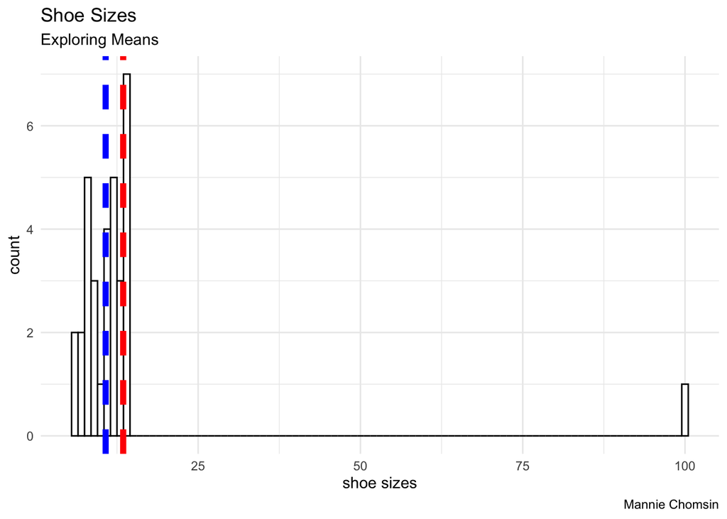

```r
ggplot(df_with_outlier, aes(x = with_outlier)) +
  geom_histogram(binwidth = 1, color = "black", fill = "white") +
  geom_vline(aes(xintercept = mean(without_outlier)),
             color = "blue", linetype = "dashed", size = 2) +
  geom_vline(aes(xintercept = mean(with_outlier)),
             color = "red", linetype = "dashed", size = 2) +
  labs(title = "Shoe Sizes", subtitle = "Exploring Means",
       caption = "Mannie Chomsin", x = "shoe sizes") +
  theme_minimal() +
  theme(legend.position = "none")
```

5. Repeat the previous task in a new code block, but compute the `median` without and with the outlier.

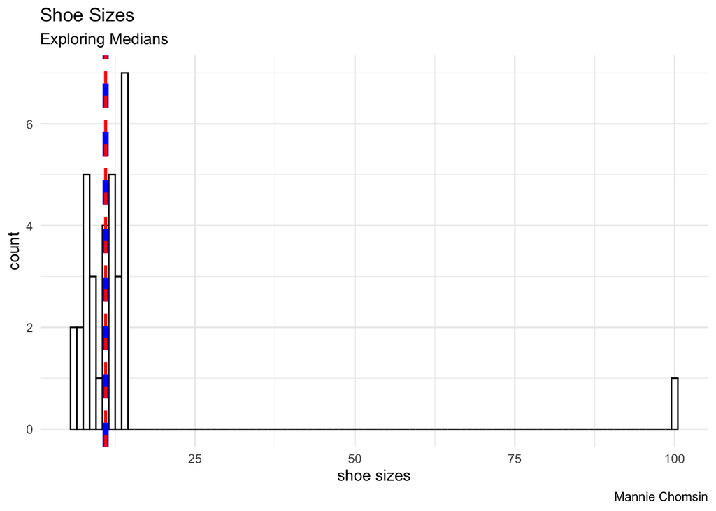

```r
ggplot(df_with_outlier, aes(x = with_outlier)) +
  geom_histogram(binwidth = 1, color = "black", fill = "white") +
  geom_vline(aes(xintercept = median(without_outlier)),
             color = "blue", linetype = "dashed", size = 2) +
  geom_vline(aes(xintercept = median(with_outlier)),
             color = "red", linetype = "dashed", size = 1) +
  labs(title = "Shoe Sizes", subtitle = "Exploring Medians",
       caption = "Mannie Chomsin", x = "shoe sizes") +
  theme_minimal() +
  theme(legend.position = "none")
```

6. Compute the *difference* between the means from before and after including the outlier. Compute the *difference* between the medians from before and after including the outlier.

```r
mean(with_outlier)-mean(without_outlier)
```

```
## [1] 2.704545
```

```r
median(with_outlier)-median(without_outlier)
```

```
## [1] 0
```

7. Make at least two observations about the results (your new graphs) in an unordered list.
- mean increases by about 2.7 when adding the outlier into the calculation
- median stays about the same, might change around 0.5 when the outlier was including in the calcualtion
8. Finally, `knit` your work as either an HTML or PDF document, and upload that document back into the CatCourses assignment.